# ECo 602 - Analysis of Environmental Data

Final Project: Data Analysis

Gabriel Toledo

Fall 2020

Everything above this line is the header.

# Introduction

This Rmarkdown is being built to help maintain a structure of knowledge in what Data Analysis is, and how to use R properly.

# Functions 1: Data Structure Functions

Look at the source code for the final project, you’ll notice the text:

{.tabset .tabset-pills}

This creates tabbed content for all the following sections that are one-level below.

- If you include them on a primary header (one #), all of the subsequent secondary headers will in tabs.

## `c()`

The following is the markdown text needed to reproduce my code example for `c()`:

The function `c()` *combines* or *concatenates* its arguments into a vector (a 1-dimensional data structure consisting of 1 or more elements).

- All of the elements must be of the same *type*.
  - I can’t combine character and numeric types in the same call to `c()`

Here’s two examples using numeric and character data types:

```r
# Create a vector of numbers:
num_vec  = c(1, 4, 8, 9, 13)

# Create a vector of characters:
char_vec = c("a", "fish", "data is cool")
```

I can show the contents of a vector by typing the name of the vector, or using the `print()` function.

```r
# Typing the name of the vector into the console prints the contents
num_vec
```

```
## [1]  1  4  8  9 13
```

```r
# The print() function accomplishes the same task:
print(char_vec)
```

```
## [1] "a"            "fish"         "data is cool"
```

## `data.frame()`

```r
#Contains the variables of a data set as columns and the observations as rows
dat_1 = data.frame(
  letters = c("b", "w", "B"),
  numbers_1 = c(34, 6, 123454))

#I can print the contents by typing the name of the data frame
dat_1
```

```
##   letters numbers_1
## 1       b        34
## 2       w         6
## 3       B    123454
```

```r
#subset a column by name
dat_1$letters
```

```
## [1] "b" "w" "B"
```

## `matrix()`

```r
#a collection of elements of the same data type arranged in rows or columns
matrix(data = NA, nrow = 1, ncol = 1, byrow = FALSE,
       dimnames = NULL)
```

```
##      [,1]
## [1,]   NA
```

```r
#setting rows and columns
mdat <- matrix(c(1,2,3, 11,12,13), nrow = 2, ncol = 3, byrow = TRUE,
               dimnames = list(c("row1", "row2"),
                               c("C.1", "C.2", "C.3")))
```

## `length()`

```r
#acquires or sets length of a function
length(y ~ x1 + x2 + x3)
```

```
## [1] 3
```

## `nrow()`

```r
#returns the number of rows in a data set
nrow(mdat)
```

```
## [1] 2
```

## `ncol()`

```r
#returns the number of columns in a data set
ncol(mdat)
```

```
## [1] 3
```

## `dim()`

```r
#returns the dimensions of a matrix
dim(mdat)
```

```
## [1] 2 3
```

# Functions 2: Numerical Data Exploration

## `summary()`

```r
#gives you a quick overview of contents of a variable

require(palmerpenguins)
penguin_dat = droplevels(subset(penguins, species != "Gentoo"))

dat_adelie = subset(penguin_dat, species == "Adelie")
dat_chinstrap = subset(penguin_dat, species == "Chinstrap")

summary(penguin_dat)
```

```
##       species          island    bill_length_mm  bill_depth_mm
##  Adelie   :152   Biscoe   : 44   Min.   :32.10   Min.   :15.50
##  Chinstrap: 68   Dream    :124   1st Qu.:37.75   1st Qu.:17.50
##                  Torgersen: 52   Median :40.60   Median :18.40
##                                  Mean   :41.91   Mean   :18.37
##                                  3rd Qu.:45.95   3rd Qu.:19.10
##                                  Max.   :58.00   Max.   :21.50
##                                  NA's   :1       NA's   :1
##  flipper_length_mm  body_mass_g       sex           year
##  Min.   :172.0     Min.   :2700   female:107   Min.   :2007
##  1st Qu.:187.0     1st Qu.:3400   male  :107   1st Qu.:2007
##  Median :191.0     Median :3700   NA's  :  6   Median :2008
##  Mean   :191.8     Mean   :3711                Mean   :2008
##  3rd Qu.:196.0     3rd Qu.:3988                3rd Qu.:2009
##  Max.   :212.0     Max.   :4800                Max.   :2009
##  NA's   :1         NA's   :1
```

## `mean()`

```r
#gives you the mean of the data
mean(dat_adelie$flipper_length_mm)
```

```
## [1] NA
```

## `sd()`

```r
#gives you the standard deviation of the data
sd(dat_adelie$flipper_length_mm)
```

```
## [1] NA
```

# Functions 3: Graphical Data Exploration

## `par()`

```r
#used to set graphical query parameters
par(mfrow = c(1,2))
```

## `plot()`

[figure not shown]

```r
#plots x,y coordinates for visual graphical exploration
plot(
  dat_adelie$flipper_length_mm ~ dat_adelie$bill_length_mm,
  cex  = 10,
  pch  = 1:25,
  col  = rainbow(25),
  main = "penguins flipper length and bill lengths",
  xlab = "flipper length",
  ylab = "bill length",
  xlim = c(170, 220),
  ylim = c(30, 60),
  data = dat_adelie
)
```

## `hist()`

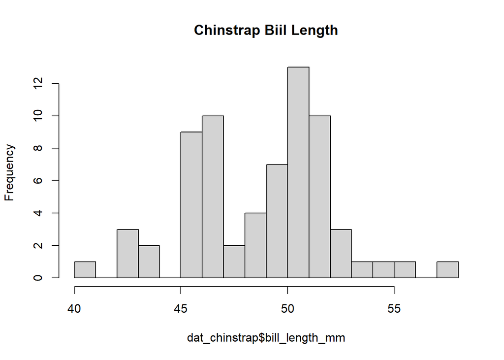

```r
#creates histograms from the data
hist(dat_chinstrap$bill_length_mm, breaks = 20, main = "Chinstrap Biil Length")
```

## `boxplot()`

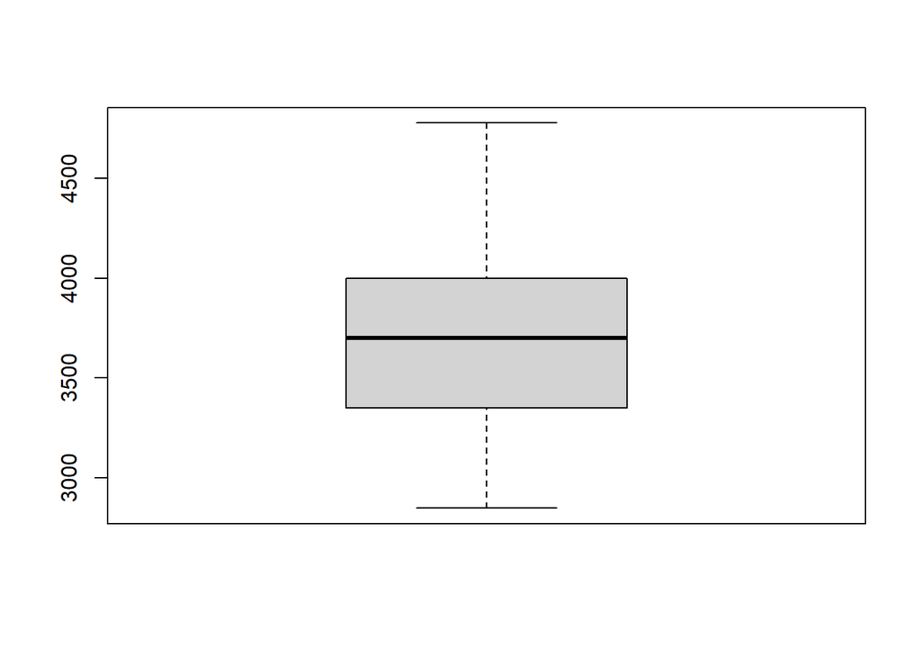

```r
#builds boxplot's for easy visualization
boxplot(dat_adelie$body_mass_g)
```

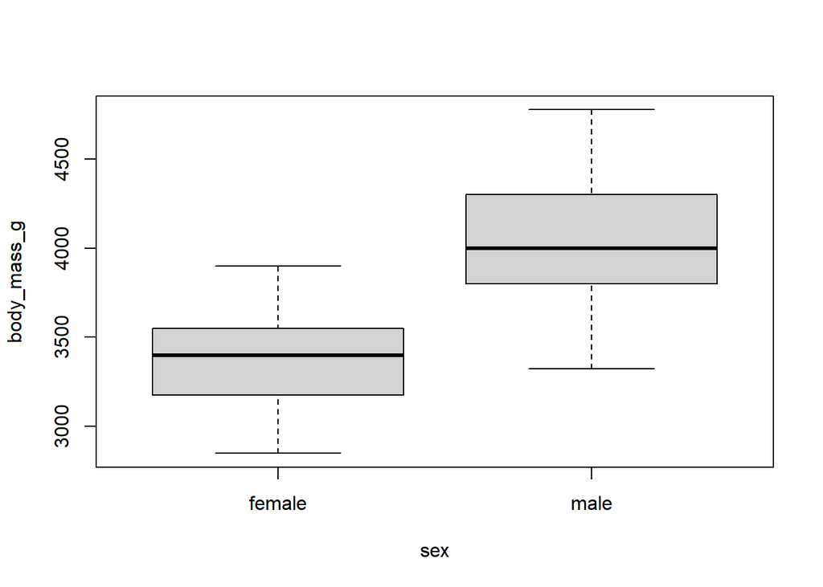

```r
boxplot(body_mass_g ~ sex, data = dat_adelie)
```

# Functions 4: Distribution Functions

## `dnorm()`

```r
#returns value of the probability density function for  a normal distribution
dnorm(0, mean = 0, sd = 1)
```

```
## [1] 0.3989423
```

## `pnorm()`

```r
#returns the integral from negative infinity q the normal distribution
pnorm(2, mean = 5, sd = 3)
```

```
## [1] 0.1586553
```

## `qnorm()`

```r
#the inverse of pnorm
qnorm(.96)
```

```
## [1] 1.750686
```

## `dbinom()`

```r
#binomial distribution, gives probability density at each point
dbinom(4, size=12, prob=0.2)
```

```
## [1] 0.1328756
```

## `pbinom()`

```r
#poisson distribution,gives cumulative probability of an event
pbinom(4, size=12, prob=0.2)
```

```
## [1] 0.9274445
```

## `qbinom()`

```r
#takes the probability values and gives a result whose cumulative value matches the probability value
qbinom(.25, 12, 0.2)
```

```
## [1] 1
```

# Functions 5: Other Functions

## `subset()`

```r
# selects subset from a data frame
dat_adelie = subset(penguin_dat, species == "Adelie")
```

## `libary()`

```r
#loads and attaches data packages
library(palmerpenguins)
```

##`require()`

```r
#loads and attaches data packages
require(palmerpenguins)
```

```r
#reads data in as a data frame

library(readr)
dat_delomys <- read_csv("Data/delomys.csv")
summary(dat_delomys)
```

```
##        X1           genus             binomial           body_mass
##  Min.   :27526   Length:1585        Length:1585        Min.   :  5.00
##  1st Qu.:27950   Class :character   Class :character   1st Qu.: 35.00
##  Median :28348   Mode  :character   Mode  :character   Median : 43.00
##  Mean   :28371                                         Mean   : 44.06
##  3rd Qu.:28790                                         3rd Qu.: 54.00
##  Max.   :35552                                         Max.   :105.00
##   body_length        age                sex              longitude
##  Min.   : 49.0   Length:1585        Length:1585        Min.   :-49681671
##  1st Qu.:106.0   Class :character   Class :character   1st Qu.:      -50
##  Median :116.0   Mode  :character   Mode  :character   Median :      -50
##  Mean   :114.7                                         Mean   :   -62739
##  3rd Qu.:124.0                                         3rd Qu.:      -47
##  Max.   :265.0                                         Max.   :      -41
##     latitude            status
##  Min.   :-22383667   Length:1585
##  1st Qu.:      -29   Class :character
##  Median :      -29   Mode  :character
##  Mean   :   -28272
##  3rd Qu.:      -24
##  Max.   :      -20
```

# Part 2: Data Anaylsis

# Numerical Exploration

## `summary`

```r
library(readr)
dat_delomys <- read_csv("Data/delomys.csv")

summary(dat_delomys$body_mass)
```

```
##    Min. 1st Qu.  Median    Mean 3rd Qu.    Max.
##    5.00   35.00   43.00   44.06   54.00  105.00
```

```r
summary(dat_delomys$body_length)
```

```
##    Min. 1st Qu.  Median    Mean 3rd Qu.    Max.
##    49.0   106.0   116.0   114.7   124.0   265.0
```

```r
shapiro.test(dat_delomys$body_mass)
```

```
##
##  Shapiro-Wilk normality test
##
## data:  dat_delomys$body_mass
## W = 0.99506, p-value = 4.33e-05
```

```r
shapiro.test(dat_delomys$body_length)
```

```
##
##  Shapiro-Wilk normality test
##
## data:  dat_delomys$body_length
## W = 0.87609, p-value < 2.2e-16
```

# Graphical Exploration

## `A scatterplot of body mass and body length`

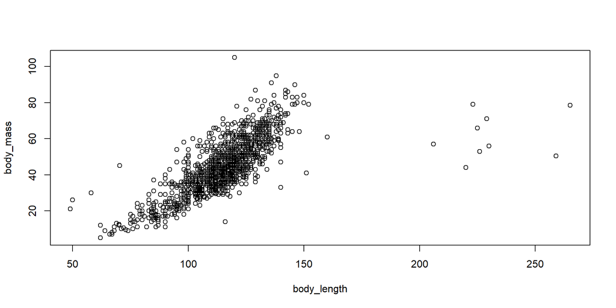

```r
plot(body_mass ~ body_length, data = dat_delomys)
```

##`A histogram of body mass`

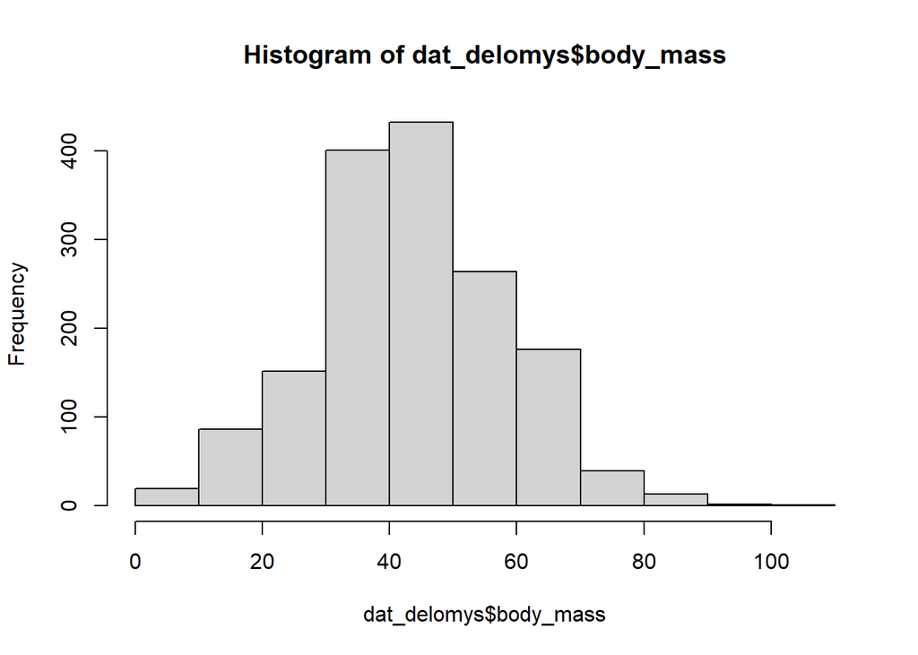

```r
hist(dat_delomys$body_mass)
```

##`A histogram of body length`

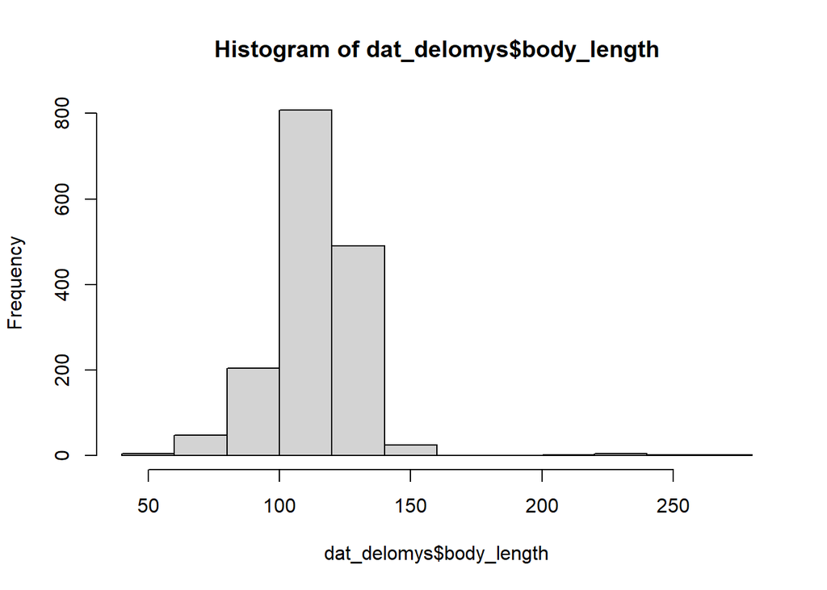

```r
hist(dat_delomys$body_length)
```

##`A conditional boxplot of body mass, conditioned on species (column binomial)`

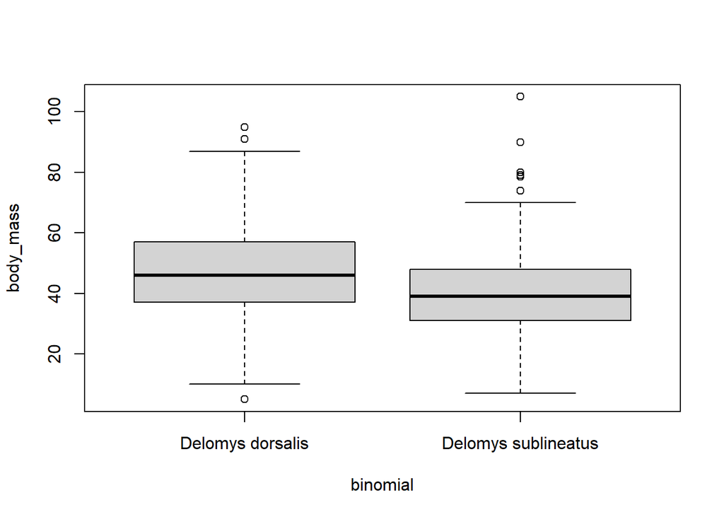

```r
boxplot(body_mass ~ binomial, data = dat_delomys)
```

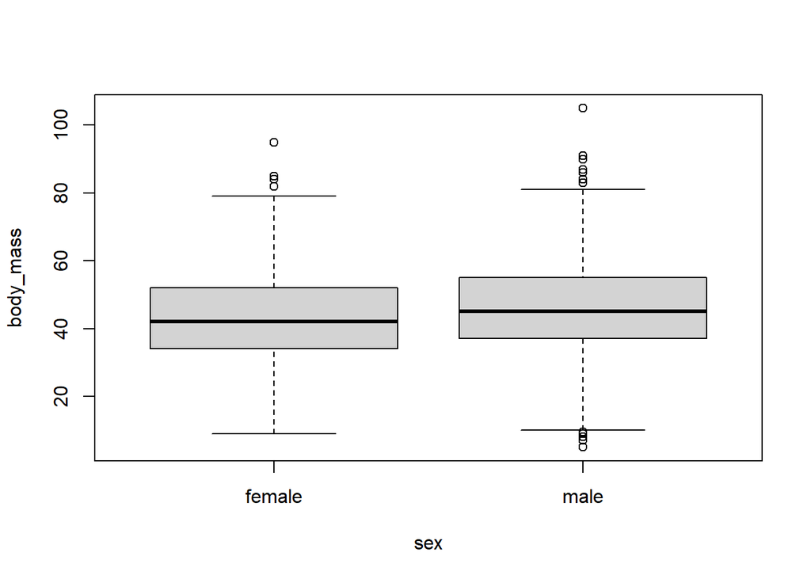

```r
boxplot(body_mass ~ sex, data = dat_delomys)
```

##`A conditional boxplot of body mass, conditioned on both species and sex`

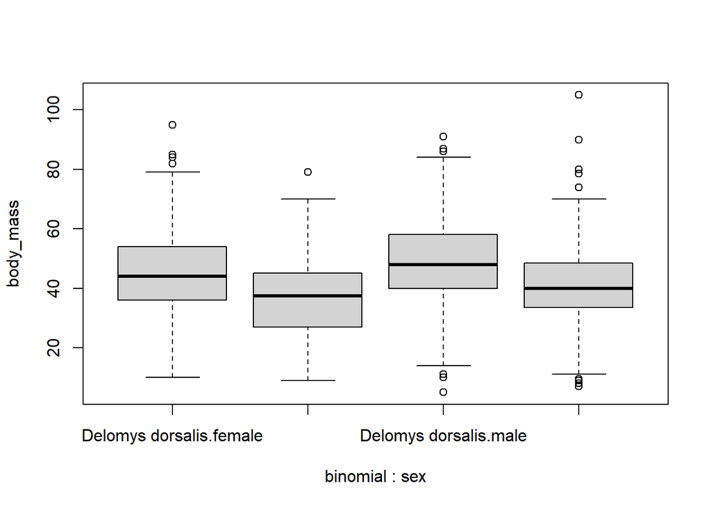

```r
boxplot(body_mass ~ binomial*sex, data = dat_delomys)
```

1.There is a very linear relationship between body mass and body length, the larger the mass the longer the body.

2.The histograms are mostly normally distributed with a few outlier’s and large peaks at the mean.

4.there are clear differences in species, where the mean body mass for Delomys dorsails is above 40 and Delomys sublineatus is right at 40. it is less clear with sex but still noticeable that females have a slightly smaller average body mass than males.

# Model Building

## `Model 1`

```r
#simple linear regression

 fit1 <- lm(body_mass ~ body_length, data = dat_delomys)
```

## `Model 2`

```r
#1-way ANOVA

fit2 <- lm(body_mass ~ sex, data = dat_delomys)
```

## `Model 3`

```r
#1-way ANOVA

fit3 <- lm(body_mass ~ binomial, data = dat_delomys)
```

## `Model 4`

```r
#2-way  additive ANOVA

fit4 <- lm(body_mass ~ sex + binomial, data = dat_delomys)
```

## `Model 5`

```r
#2-way factorial ANOVA

fit5 <- lm(body_mass ~ sex * binomial, data = dat_delomys)
```

# Model diagnostics

## `Model 1`

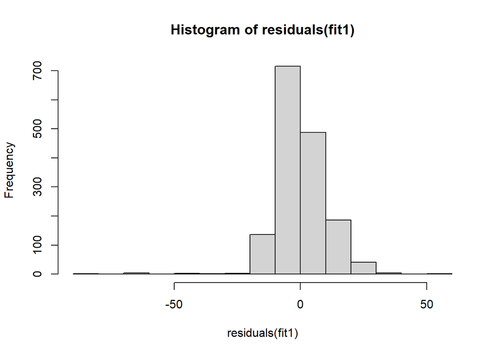

```r
#simple linear regression

hist(residuals(fit1))
```

```r
shapiro.test(residuals(fit1))
```

```
##
##  Shapiro-Wilk normality test
##
## data:  residuals(fit1)
## W = 0.91563, p-value < 2.2e-16
```

## `Model 2`

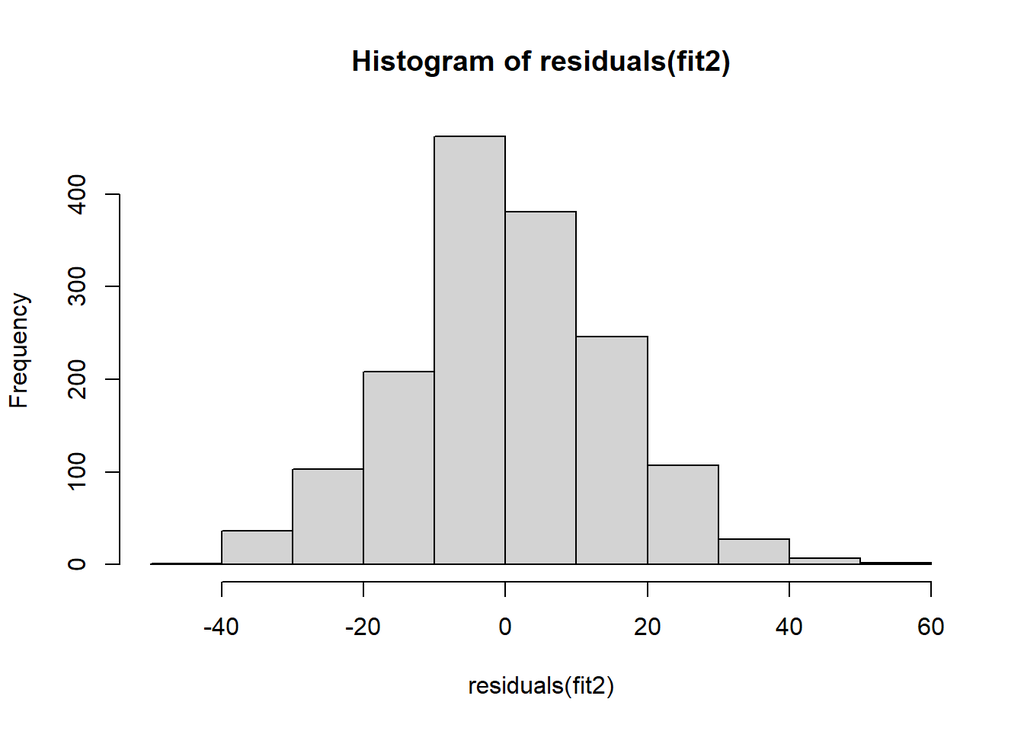

```r
#1-way ANOVA

hist(residuals(fit2))
```

```r
shapiro.test(residuals(fit2))
```

```
##
##  Shapiro-Wilk normality test
##
## data:  residuals(fit2)
## W = 0.99563, p-value = 0.0001541
```

## `Model 3`

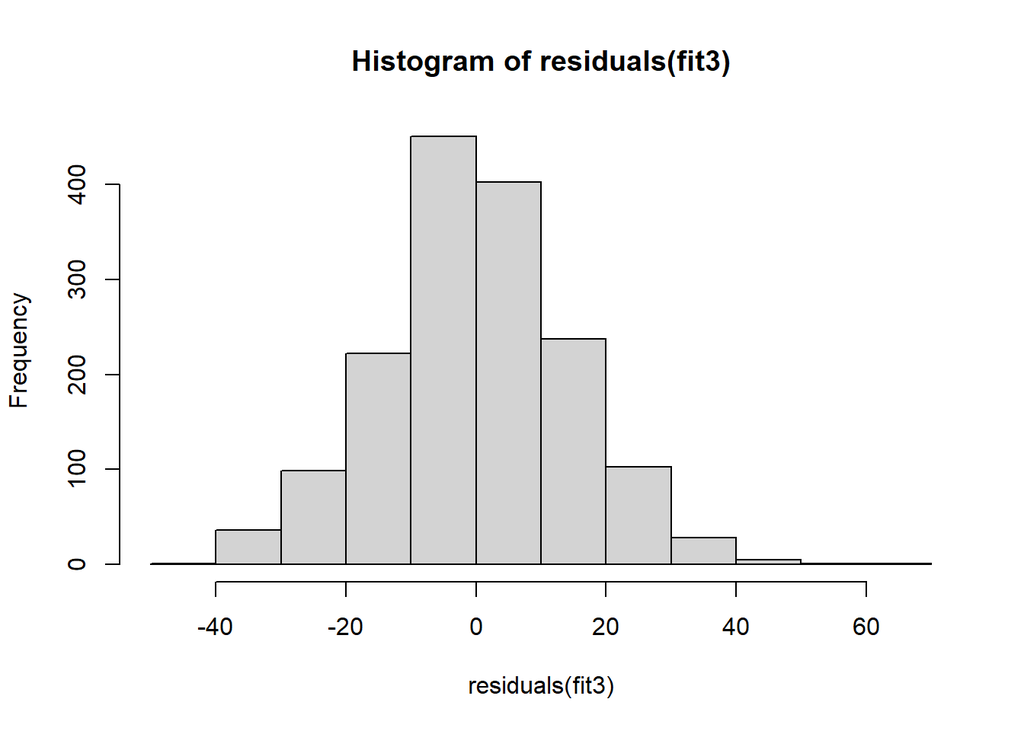

```r
#1-way ANOVA

hist(residuals(fit3))
```

```r
shapiro.test(residuals(fit3))
```

```
##
##  Shapiro-Wilk normality test
##
## data:  residuals(fit3)
## W = 0.99535, p-value = 8.103e-05
```

## `Model 4`

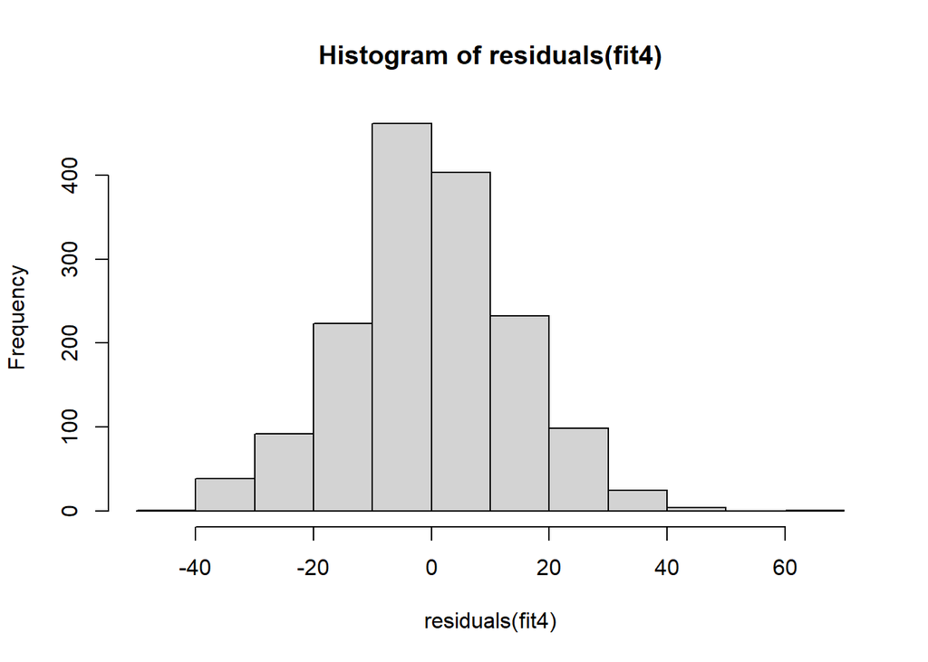

```r
#2-way  additive ANOVA

hist(residuals(fit4))
```

```r
shapiro.test(residuals(fit4))
```

```
##
##  Shapiro-Wilk normality test
##
## data:  residuals(fit4)
## W = 0.99525, p-value = 6.805e-05
```

## `Model 5`

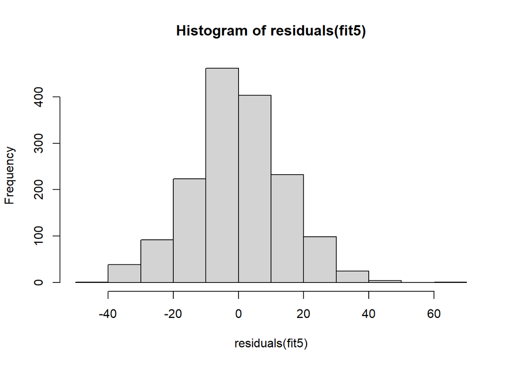

```r
#2-way factorial ANOVA

hist(residuals(fit5))
```

```r
shapiro.test(residuals(fit5))
```

```
##
##  Shapiro-Wilk normality test
##
## data:  residuals(fit5)
## W = 0.99526, p-value = 6.816e-05
```

# Model Interpretation

## `Body Length`

```r
knitr::kable(coef(summary(fit1)))
```

|  | Estimate | Std. Error | t value | Pr(>\|t\|) |
| --- | --- | --- | --- | --- |
| (Intercept) | -28.6930718 | 1.6552332 | -17.33476 | 0 |
| body_length | 0.6343032 | 0.0142659 | 44.46298 | 0 |

## `Body Mass: Model Coefficients`

```r
knitr::kable(coef(summary(fit2)))
```

|  | Estimate | Std. Error | t value | Pr(>\|t\|) |
| --- | --- | --- | --- | --- |
| (Intercept) | 42.711465 | 0.5288929 | 80.756355 | 0.0000000 |
| sexmale | 2.784133 | 0.7456117 | 3.734024 | 0.0001951 |

```r
knitr::kable(coef(summary(fit3)))
```

|  | Estimate | Std. Error | t value | Pr(>\|t\|) |
| --- | --- | --- | --- | --- |
| (Intercept) | 46.752427 | 0.4499933 | 103.89582 | 0 |
| binomialDelomys sublineatus | -7.683058 | 0.7604562 | -10.10322 | 0 |

```r
knitr::kable(coef(summary(fit4)))
```

|  | Estimate | Std. Error | t value | Pr(>\|t\|) |
| --- | --- | --- | --- | --- |
| (Intercept) | 45.070355 | 0.5556429 | 81.113891 | 0e+00 |
| sexmale | 3.795395 | 0.7259609 | 5.228099 | 2e-07 |
| binomialDelomys sublineatus | -8.193492 | 0.7609985 | -10.766764 | 0e+00 |

```r
knitr::kable(coef(summary(fit5)))
```

|  | Estimate | Std. Error | t value | Pr(>\|t\|) |
| --- | --- | --- | --- | --- |
| (Intercept) | 45.0554562 | 0.6052973 | 74.4352459 | 0.0000000 |
| sexmale | 3.8280908 | 0.8966667 | 4.2692460 | 0.0000208 |
| binomialDelomys sublineatus | -8.1417394 | 1.1281046 | -7.2171847 | 0.0000000 |
| sexmale:binomialDelomys sublineatus | -0.0950187 | 1.5285856 | -0.0621612 | 0.9504424 |

- Female:42.711465
- Delomys dorsils:46.752427
- The male sex is heavier
- The Delomys dorsil is heavier

## `Body Mass: ANOVA`

```r
knitr::kable(anova(fit2))
```

|  | Df | Sum Sq | Mean Sq | F value | Pr(>F) |
| --- | --- | --- | --- | --- | --- |
| sex | 1 | 3061.678 | 3061.6779 | 13.94294 | 0.0001951 |
| Residuals | 1578 | 346507.131 | 219.5863 | NA | NA |

```r
knitr::kable(anova(fit3))
```

|  | Df | Sum Sq | Mean Sq | F value | Pr(>F) |
| --- | --- | --- | --- | --- | --- |
| binomial | 1 | 21289.68 | 21289.6805 | 102.0751 | 0 |
| Residuals | 1583 | 330164.45 | 208.5688 | NA | NA |

```r
knitr::kable(anova(fit4))
```

|  | Df | Sum Sq | Mean Sq | F value | Pr(>F) |
| --- | --- | --- | --- | --- | --- |
| sex | 1 | 3061.678 | 3061.6779 | 14.95838 | 0.0001144 |
| binomial | 1 | 23727.134 | 23727.1342 | 115.92320 | 0.0000000 |
| Residuals | 1577 | 322779.997 | 204.6798 | NA | NA |

```r
knitr::kable(anova(fit5))
```

|  | Df | Sum Sq | Mean Sq | F value | Pr(>F) |
| --- | --- | --- | --- | --- | --- |
| sex | 1 | 3.061678e+03 | 3.061678e+03 | 14.948932 | 0.0001150 |
| binomial | 1 | 2.372713e+04 | 2.372713e+04 | 115.849977 | 0.0000000 |
| sex:binomial | 1 | 7.913846e-01 | 7.913846e-01 | 0.003864 | 0.9504424 |
| Residuals | 1576 | 3.227792e+05 | 2.048091e+02 | NA | NA |

- Sex and species are great predictors for body mass
- There is not a significant interaction between sex and species

## `Model Comparison: Body Mass`

```r
AIC(fit2)
```

```
## [1] 13006.8
```

```r
AIC(fit3)
```

```
## [1] 12966.36
```

```r
AIC(fit4)
```

```
## [1] 12896.73
```

```r
AIC(fit5)
```

```
## [1] 12898.72
```

- Fit4 has the lowest AIC at 12896.73 and fit5 has the next lowest AIC at 12898.72
- I would choose fit4 not only does it have the lowest AIC but it also has less information than fit5 which might be nice for an easy interpretation of the data.